# SAE202_CORRECTION

SAÉ202  
Exploration algorithmique d'un problème

L'objectif de cette SAE est d'explorer la représentation de l'ensemble de Mandelbrot. A cette fin, nous développons le langage des nombres complexes.

Ce notebook contient du cours et des exercices qu'il vous appartient de vous approprier et de poser les questions qui s'imposent à vos enseignants lors des séances de travail en autonomie ; il vous suffit d'un @Davidhebert sur Discord pour des éclaircicement ; des séances de soutien sont également proposé dans votre emplois du temps.  
**Vous aurez une évaluation sur la partie mathématiques de ce contenu (pas d'évaluation sur le python).**

Bibliothèque `math`

Pour réaliser des opérations mathématiques nous auront besoin de la bibliothèque éponyme. Executez la case suivante pour charger ses fonctionnalités

```python
from math import *
```

Une fois chargée, voici ce que vous pouvez à présent faire:

| Mathématiques | Python |
| --- | --- |
| $\|x\|$ | `abs(x)` |
| $\sqrt{x}$ | `sqrt(x)` |
| $e^x$ | `exp(x)` |
| $ln(x)$ | `log(x)` |
| $log(x)$ | `log10(x)` |
| $cos(x)$ | `cos(x)` |
| $sin(x)$ | `sin(x)` |
| $tan(x)$ | `tan(x)` |
| $Arctan(x)$ | `atan(x)` |
| $\pi$ | `pi` |
| $e(=e^1)$ | `e` |
| $x^y$ | `pow(x, y)` |
| $n!$ | `factorial(n)` |

### Exercice

1. Donner une valeur approchée de $\sqrt{2}$.
2. Donner une valeur approchée du [nombre d'or](https://fr.wikipedia.org/wiki/Nombre_d%27or).
3. Donner une valeur approchée de $sin(666)$.
4. Donner une valeur approchée d'un angle $\vartheta$ tel que $tan(\vartheta)=\sqrt{3}$.
5. Donner une valeur approchée de $tan\left(\dfrac{\pi}{2}\right)$.
6. Donner la valeur de $666!$.

```python
print("1°)", sqrt(2) )
print("2°)", (1+sqrt(5))/2 )
print("3°)", sin(666) )
print("4°)", atan(sqrt(3)) )
print("5°)", tan(pi/2) )
print("6°)", factorial(666) )
```

```
1°) 1.4142135623730951
2°) 1.618033988749895
3°) -0.01764164581327013
4°) 1.0471975511965976
5°) 1.633123935319537e+16
6°) 101063205684078149339082270812987645175758239832414541134042…
```

Graphiques en python

# Première partie : les listes

Pour pouvoir réaliser des graphiques en python, nous avons besoin de spécifier des listes (de points). La fonction de base est la fonction `range` qui permet très rapidement d'énumeré des entiers (et non des nombres décimaux). Voici les trois utilisations possible :

1. `range(n)` qui donne la liste des entiers de `0` à `n-1`. Par exemple `range(10)` donnera `[0, 1, 2, 3, 4, 5, 6, 7, 8, 9]`
2. `range(a, b)` qui donne la liste des entiers entre `a` et `b-1`. Par exemple `range(3, 10)` donnera `[3, 4, 5, 6, 7, 8, 9]`
3. `range(a, b, p)` qui donne la liste des entiers entre `a` et `b-1` par bond de `p`. Par exemple `range(3, 10, 3)` donnera `[3, 6, 9]`

### Exercice

Donner les entiers entre $0$ et $1983$ qui sont dans la table de $23$ (il y en a 87).

```python
print(list(range(0, 1983, 23)))
```

```
[0, 23, 46, 69, 92, 115, 138, 161, 184, 207, 230, 253, 276, 299, 322, 345, 368, 391, 414, 437, 460, 483, 506, 529, 552, 575, 598, 621, 644, 667, 690, 713, 736, 759, 782, 805, 828, 851, 874, 897, 920, 943, 966, 989, 1012, 1035, 1058, 1081, 1104, 1127, 1150, 1173, 1196, 1219, 1242, 1265, 1288, 1311, 1…
```

Il est possible de créer des listes de nombres pas forcément entiers de la manière suivante :

> `y=[fonction de x for x in valeur]`

Dans ce cas la liste `y` aura dans chacune de ses cases la valeur de `f(x)` pour les différentes valeurs prises par `x`. Voici des exemples :

1. > `y=[x**2/10 for x in range(1, 10, 2)]`

   alors `y=[0.1, 0.9, 2.5, 4.9, 8.1]`
2. > `z=[pow(abs(t), t/2 ) for t in range(-10, 10, 1)]`

   alors `z=[1e-05, 5.080526342529086e-05, 0.000244140625, 0.001101937239093957, 0.004629629629629629, 0.01788854381999832, 0.0625, 0.19245008972987526, 0.5, 1.0, 1.0, 1.0, 2.0, 5.196152422706632, 16.0, 55.90169943749474, 216.0, 907.4926996951546, 4096.0, 19683.0]`

# Seconde partie : Les graphiques

Comme pour les fonctions, il faut définir la fenêtre de graphique. Par chance, d'autre s'en sont occupés. Chargeons cette fonctionnalité : exécuter la case suivante.

```python
from matplotlib.pyplot import *
```

Pour faire un graphique rien de plus simple ! On utilise la fonction `plot` qui prend au moins deux paramètres :

1. Le premier est la liste des points d'abscisses
2. La seconde est la liste des points d'ordonnées

Voici un exemple :

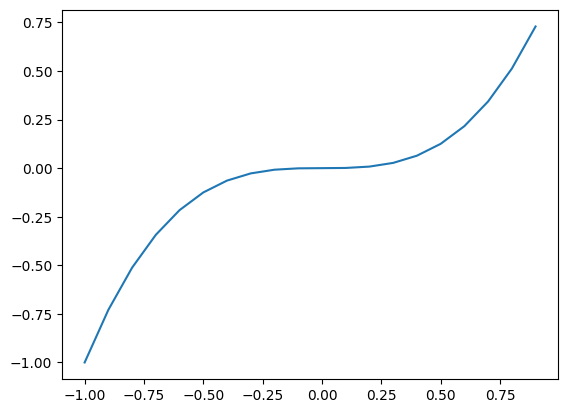

```python
X=[x/10 for x in range(-10, 10)] #On calcule les abscisses
Y=[x**3 for x in X]#On calcule les ordonnées
plot(X, Y)#On fait le dessin
show()#On affiche le dessin
```

### Exercice

Dessiner la fonction exponentielle sur $[-10, 2]$

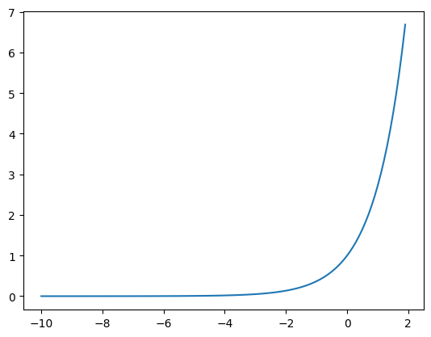

```python
X=[x/10 for x in range(-100, 20)]
Y=[exp(x) for x in X]
plot(X, Y)
show()
```

### Quelques fonctionnalités supplémentaires

- `grid(True)` permet d'afficher une grille dans le graphique. Exemple :

  > ```
  > plot(X, Y)
  > grid(True)
  > ```

- On peut modifier la couleur de la courbre en ajoutant un paramètre à la fonction `plot`, comme dans l'exemple suivant :

  > `plot(X, Y, 'k')`

  Les différentes couleurs prédéfinies sont :

  | Couleur | Code |
  | --- | --- |
  | Bleu | `'b'` |
  | Vert | `'g'` |
  | Rouge | `'r'` |
  | Cyan | `'c'` |
  | Magenta | `'m'` |
  | Jaune | `'y'` |
  | Noir | `'k'` |
  | Blanc | `'w'` |

- On peut préciser le style de la ligne parmi les choix suivant :

  | Style | Code |
  | --- | --- |
  | Ligne continue (par défaut) | `'-'` |
  | Tiret | `'--'` |
  | Pointillé | `':'` |

  > `plot(X, Y, ':')`

  **ATTENTION** cependant ! Si vous voulez modifier la couleur et le style du trait, il faut le faire en même temps. De sorte que `plot(X, Y, ':', 'r')` est une erreur. On corrigera par

  > `plot(X, Y, 'r:')`
- La fonction `plot(X, Y)` place par défaut des points (ceux de `X` et `Y`) et les relie par des traits (où d'autre style comme nous l'avons vu précédement). On peut changer le style des marques parmi ceux de la liste suivante :

  | Marqueur | Code |
  | --- | --- |
  | Point (par défaut) | `'.'` |
  | Cercle | `'o'` |
  | Triangle vers le bas | `'v'` |
  | Triangle vers le haut | `'^'` |
  | Triangle vers la gauche | `'<'` |
  | Triangle vers la droite | `'>'` |
  | Carré | `'s'` |
  | Pentagone | `'p'` |
  | Etoile | `'*'` |
  | Plus | `'+'` |
  | Croix | `'x'` |
  | Losange | `'d'` |

  Il en existe quelque autres. Comme pour les styles de traits, il faut déclarer les marqueurs au même moment.

  > `plot(X, Y, 'rd:')`
- On peut préciser l'épaisseur de la ligne en ajoutant à la fonction `plot` la paramètre `linewidth`.

  > `plot(X, Y, linewidth=5)`
- On peut préciser les bords de la fenêtre de graphique par l'appel des fonction `xlim` et `ylim` qui prennent chacun deux paramètres : la plus grande et la plus petite valeur sur les axes respectifs.

  > ```
  > plot(X, Y)
  > xlim(-1,1)
  > ylim(-10, 10)
  > ```

- On peut donner un titre au graphique par l'appel de la fonction `title`

  > ```
  > plot(X, Y)
  > title("Graphique de ma fonction")
  > ```

- On peut déssiner plusieurs fonctions sur un même graphique (par l'appel de plusieurs `plot` différent). Dans ce cas, pour les disctinguer (en plus des couleurs), on peut légender les différentes courbes. Il y a pour cela deux choses à faire :
  1. Donner un titre à la courbe, en ajoutant un `label` dans `plot`.
  2. Demander l'affichage de ce `label`. Pour cela on appel la fonction `legend` sans paramètre.

  > ```
  > plot(X, Y, label="Fonction 1")
  > plot(X, Z, label="Fonction 2")
  > legend()
  > ```

- On peut aussi labéliser les axes : `xlabel` pour les abscisses et `ylabel` pour les ordonnées.

  > ```
  > plot(X, Y)
  > xlabel("Abscisses")
  > ylabel("Ordonnées")
  > ```

Voici un exemple qui résume tout *(dans les label a été placé du code $\LaTeX$ qui est un langage d'édition d'équation compris par Jupyter. N'y prétez pas attention, et admirez le résultat)*.

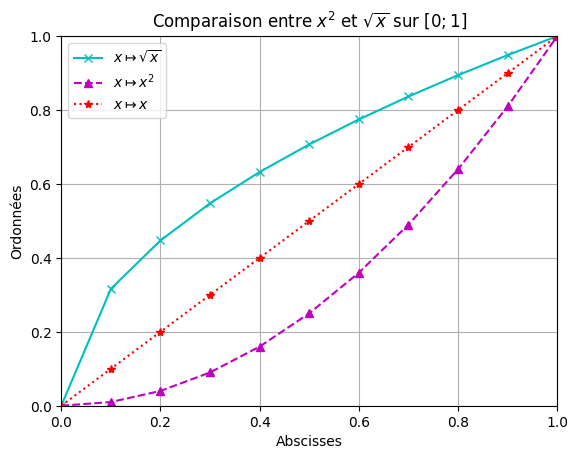

```python
#Coordonnes des points
X=[x/10 for x in range(10+1)]
Y=[sqrt(x) for x in X]
Z=[x**2 for x in X]

#Dessin
plot(X, Y, 'cx-', linewidth=1.5, label="$x\mapsto \sqrt{x}$")
plot(X, Z, 'm^--', label="$x\mapsto x^2$")
plot(X, X, 'r*:', label="$x\mapsto x$")

#Dimension de la fenêtre
xlim(0, 1)
ylim(0, 1)

#Titre et légende
title("Comparaison entre $x^2$ et $\sqrt{x}$ sur $[0; 1]$")
xlabel("Abscisses")
ylabel("Ordonnées")
legend()

#Quadrillage
grid(True)

#Affichage
show()
```

### Exercices

Déssiner $x\mapsto e^x$ et $x\mapsto ln(x)$ entre sur $[-2 ; 4]$ (attention le logarithme n'est pas définie (normalement) sur les réels négatifs). Tracer également la droite $x\mapsto x$ et les axes du repère

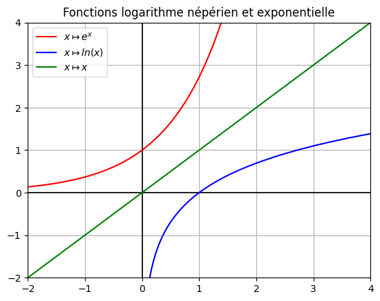

```python
X=[x/100 for x in range(-200, 400+1)]

#Axes
plot([-2, 4], [0, 0], 'k', linewidth=1.19)
plot([0, 0], [-2, 4], 'k', linewidth=1.19)

#Fonction exponentielle
Y=[exp(x) for x in X]
plot(X, Y, 'r', label="$x\mapsto e^x$")

#Fonction logarithme
plot([x for x in X if x>0], [log(x) for x in X if x>0], 'b', label="$x\mapsto ln(x)$")

#Droite Y=X
plot(X, X, 'g', label="$x\mapsto x$")

title("Fonctions logarithme népérien et exponentielle")

xlim(-2, 4)
ylim(-2, 4)

legend()

grid(True)

show()
```

# Troisème partie : les rectangles

Pour aboutir à notre résultat de la réprésentation de l'ensemble de mandelbrot, nous allons réaliser des dessins en pixelart. Pour cela nous allons utiliser la fonction `Rectangle( (x, y), longueur, hauteur )` qui prend en paramètre :

- `(x, y)` les coordonnées cartésienne du coin inférieur gauche du rectangle
- `longueur` la longueur du rectangle
- `hauteur` la hauteur du rectangle

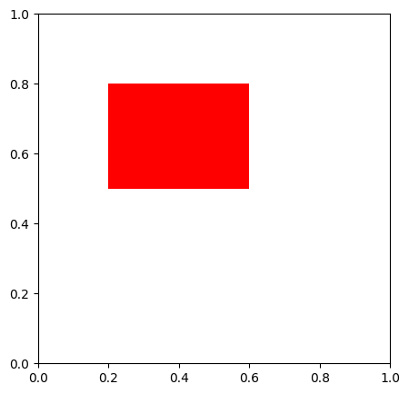

```python
# Crée un graphique vide
fig, ax = subplots(figsize=(5, 5))#figsize permet de préciser la taille de la fenetre (largeur, hauteur)

# Ajoute un rectangle au graphique
rect = Rectangle((0.2, 0.5), 0.4, 0.3, facecolor='red')
ax.add_patch(rect)

# Affiche le graphique
show()
```

Voici des variables contenant des coordonnées de carré à dessiner avec la couleur spécifiée par le nom de la variable. La taille de ces carrés sont de 1 (en longueur et hauteur). On pourra prendre `xlim(0, 43)`, `ylim(0, 28)` et `figsize=(9, 6)`.

Représentez ce pixelart.

```python
BLACK = [[32, 9], [16, 11], [15, 13], [29, 17], [14, 5], [23, 21], [19, 3], [17, 4], [11, 8], [23, 8], [32, 25], [24, 3], [33, 24], [26, 11], [15, 12], [14, 23], [11, 25], [12, 12], [12, 17], [27, 21], [12, 24], [33, 19], [26, 12], [33, 21], [34, 22], [25, 13], [31, 14], [34, 23], [8, 25], [22, 8], [20, 7], [11, 18], [15, 5], [34, 24], [25, 4], [18, 20], [18, 12], [25, 20], [26, 13], [20, 3], [8, 26], [26, 14], [20, 21], [33, 20], [23, 6], [23, 3], [28, 12], [34, 21], [18, 13], [31, 12], [10, 20], [30, 16], [13, 15], [30, 15], [13, 23], [33, 23], [16, 14], [9, 21], [13, 6], [21, 21], [10, 23], [26, 21], [10, 25], [8, 23], [32, 18], [27, 11], [35, 25], [28, 22], [26, 4], [31, 7], [17, 21], [16, 4], [10, 22], [21, 11], [18, 4], [29, 23], [9, 22], [12, 14], [22, 5], [31, 24], [17, 14], [34, 25], [17, 11], [8, 24], [10, 21], [24, 20], [25, 12], [9, 23], [21, 9], [19, 9], [12, 11], [12, 7], [16, 21], [16, 12], [11, 10], [28, 13], [22, 11], [30, 6], [35, 26], [15, 22], [28, 5], [11, 9], [20, 8], [29, 5], [17, 12], [19, 20], [34, 26], [10, 24], [21, 5], [22, 21], [22, 3], [21, 8], [27, 14], [31, 17], [30, 23], [23, 7], [33, 25], [9, 25], [12, 13], [20, 6], [31, 13], [9, 26], [35, 23], [33, 22], [13, 16], [27, 4], [22, 9], [21, 3], [35, 24], [17, 13], [24, 9], [9, 24], [14, 17], [32, 8], [10, 19], [32, 10], [31, 11], [27, 12]]
RED = [[28, 10], [14, 9], [15, 8], [29, 8], [30, 9], [28, 8], [29, 7], [29, 9], [14, 7], [28, 7], [13, 9], [13, 8], [30, 8], [22, 6], [15, 10], [29, 10], [16, 8], [28, 9], [16, 9], [15, 9], [21, 6], [27, 9], [14, 10], [22, 7], [21, 7], [27, 8], [15, 7], [14, 8]]
YELLOW = [[28, 15], [19, 11], [13, 7], [21, 16], [20, 20], [12, 23], [25, 5], [23, 13], [26, 20], [24, 10], [32, 22], [31, 21], [17, 9], [24, 5], [11, 21], [22, 17], [14, 11], [26, 19], [19, 17], [18, 18], [16, 5], [31, 9], [14, 15], [24, 8], [14, 21], [13, 20], [30, 22], [23, 14], [22, 16], [22, 4], [17, 6], [23, 19], [17, 10], [17, 7], [26, 17], [19, 14], [13, 14], [30, 11], [12, 10], [20, 19], [31, 18], [17, 20], [11, 19], [15, 20], [24, 17], [23, 20], [28, 6], [25, 7], [22, 14], [21, 19], [27, 5], [18, 17], [25, 11], [32, 24], [22, 18], [19, 16], [15, 6], [23, 4], [19, 7], [24, 13], [18, 14], [30, 14], [12, 19], [19, 10], [18, 16], [26, 7], [28, 16], [27, 10], [27, 16], [19, 19], [16, 6], [25, 9], [18, 10], [28, 19], [18, 5], [24, 12], [19, 15], [14, 20], [28, 17], [18, 7], [29, 6], [20, 11], [13, 21], [23, 15], [27, 18], [29, 15], [20, 13], [15, 14], [14, 13], [19, 8], [26, 16], [16, 18], [12, 9], [22, 13], [21, 15], [15, 18], [13, 19], [24, 6], [19, 19], [19, 4], [29, 18], [28, 11], [30, 20], [13, 17], [15, 21], [17, 16], [23, 10], [29, 11], [27, 15], [24, 18], [13, 18], [11, 20], [32, 23], [25, 8], [30, 12], [21, 4], [25, 10], [16, 19], [26, 10], [26, 5], [29, 20], [20, 12], [30, 18], [16, 17], [21, 10], [18, 11], [23, 17], [14, 6], [25, 19], [30, 13], [20, 4], [13, 22], [26, 9], [31, 10], [11, 23], [18, 15], [24, 19], [24, 11], [23, 18], [22, 12], [32, 20], [12, 8], [28, 18], [11, 22], [28, 21], [12, 21], [25, 16], [25, 15], [16, 16], [29, 19], [21, 14], [19, 5], [25, 6], [16, 15], [15, 19], [24, 19], [20, 14], [29, 14], [28, 20], [21, 13], [11, 24], [24, 4], [15, 11], [14, 22], [18, 19], [14, 18], [13, 12], [24, 15], [31, 22], [21, 18], [15, 15], [17, 17], [17, 19], [27, 6], [22, 19], [21, 12], [22, 15], [24, 14], [17, 8], [30, 19], [13, 13], [20, 18], [28, 14], [27, 17], [29, 22], [26, 18], [12, 18], [23, 9], [17, 5], [20, 5], [12, 20], [30, 17], [31, 23], [29, 12], [30, 10], [20, 10], [15, 17], [23, 12], [14, 12], [24, 16], [17, 15], [16, 10], [19, 18], [31, 20], [23, 5], [29, 16], [21, 17], [12, 22], [32, 21], [31, 8], [15, 16], [30, 21], [27, 19], [19, 6], [18, 6], [22, 20], [25, 18], [18, 8], [26, 15], [19, 12], [30, 7], [16, 7], [32, 19], [14, 19], [19, 13], [25, 14], [23, 16], [24, 7], [26, 8], [22, 10], [27, 7], [26, 6], [16, 20], [29, 13], [20, 16], [20, 17], [20, 15], [20, 9], [18, 9], [14, 16], [29, 21], [17, 18], [13, 10], [31, 19], [27, 20], [25, 17], [13, 11], [21, 20], [14, 14], [23, 11]]
```

[figure not shown]

```python
fig, ax = subplots(figsize=(9, 6))

xlim(0, 43)
ylim(0, 28)

for P in BLACK :
    x=P[0]
    y=P[1]
    rect = Rectangle((x, y), 1, 1, facecolor='black')
    ax.add_patch(rect)
for P in RED :
    x=P[0]
    y=P[1]
    rect = Rectangle((x, y), 1, 1, facecolor='red')
    ax.add_patch(rect)
for P in YELLOW :
    x=P[0]
    y=P[1]
    rect = Rectangle((x, y), 1, 1, facecolor='yellow')
    ax.add_patch(rect)

show()
```

Les nombres complexes

# Première partie : représentation cartésienne.

On note $i$ une solution de l'équation $x^2+1=0$. C'est un nombre *imaginaire pure*. De manière générale un **nombre complexe est la donnée de $z=x+iy$** où $x$ est appelé la partie réelle et $y$ la partie imaginaire. Informatiquement, un nombre complexe est la donnée d'une liste à deux entrées. La première coordonnée est la partie réel et la seconde la partie imaginaire.

Voici des exemples

```python
Z1=[sqrt(3)/2, -1/2] #Représente le nombre complexe z1=sqrt(3)/2+i(-1/2)
Z2=[1/2, sqrt(3)/2] #Représente le nombre complexe z2=1/2+isqrt(3)/2
Z3=[0, 1] #Représente le nombre complexe i
```

Écrire la fonction `partieReelle_car(z)` qui prend en paramètre un nombre complexe (une liste à deux entrées) et renvoie la partie réelles (un nombre réel).

```python
def partieReelle_car(z) :
    return z[0]
```

```python
#Tests
print(partieReelle_car(Z1))#0.8660254037844386
print(partieReelle_car(Z2))#0.5
print(partieReelle_car(Z3))#0
```

```
0.8660254037844386
0.5
0
```

De même, écrire la fonction `partieImaginaire_car(z)` qui renvoie la partie imaginaire

```python
def partieImaginaire_car(z) :
    return z[1]
```

```python
#Tests
print(partieImaginaire_car(Z1))#-0.5
print(partieImaginaire_car(Z2))#0.8660254037844386
print(partieImaginaire_car(Z3))#1
```

```
-0.5
0.8660254037844386
1
```

La procédure suivante, prend en paramètre un nombre complexe et affiche ce nombre. Le paramètre optionnel `precision` permet de spécifier le nombre de chiffre après la virgule qui doivent apparaitre.

```python
def printZ_car(z, precision=2) :
    x=round(partieReelle_car(z), precision)
    y=round(partieImaginaire_car(z), precision)

    txt=""
    if(x==0 and y==0) : txt=0

    if(x!=0) : txt+=str(x)
    if(y>0 and x!=0) : txt+='+'
    if(abs(y)!=1 and y!=0) : txt+=str(y)
    if(y==-1) : txt+='-'
    if(y!=0) : txt+='i'

    print(txt)
```

```python
#Tests
printZ_car(Z1)#0.87-0.5i
printZ_car(Z2)#0.5+0.87i
printZ_car(Z3)#i
```

```
0.87-0.5i
0.5+0.87i
i
```

### Somme algébrique de nombre complexe

Si $z_1=x_1+iy_1$ et $z_2=x_2+iy_2$ sont deux nombres complexes alors on définit l'addition $$z_1+z_2=(x_1+x_2)+i(y_1+y2)$$ En définitive, on additionne les nombres complexes comme des nombres réels usuelles en considérant le nombre complexe $i$ comme une variable.

Écrire la fonction `addZ_car(z1, z2)` qui renvoie le nombre complexe `z1+z2`

```python
def addZ_car(z1, z2) :
    return [partieReelle_car(z1)+partieReelle_car(z2), partieImaginaire_car(z1)+partieImaginaire_car(z2)]
```

```python
#Tests
printZ_car(addZ_car(Z1, Z2))#1.37+0.37i
printZ_car(addZ_car(Z1, Z3))#0.87+05i
printZ_car(addZ_car(Z2, Z3))#0.5+1.87i
```

```
1.37+0.37i
0.87+0.5i
0.5+1.87i
```

Écrire la fonction `oppZ_car(z)` qui renvoie l'opposé du nombre complexe `z`.

```python
def oppZ_car(z) :
    return [-partieReelle_car(z), -partieImaginaire_car(z)]
```

```python
#Tests
printZ_car(oppZ_car(Z1))#-0.87+0.5i
printZ_car(oppZ_car(Z2))#-0.5-0.87i
printZ_car(oppZ_car(Z3))#-i
```

```
-0.87+0.5i
-0.5-0.87i
-i
```

En déduire la fonction `sousZ_car(z1, z2)` qui renvoie le nombre complexe `z1-z2`.

```python
def sousZ_car(z1, z2) :
    return addZ_car(z1, oppZ_car(z2))
```

```python
#tests
printZ_car(sousZ_car(Z1, Z2))#0.37-1.37i
printZ_car(sousZ_car(Z1, Z3))#0.87-1.5i
printZ_car(sousZ_car(Z2, Z3))#0.5-0.13i
```

```
0.37-1.37i
0.87-1.5i
0.5-0.13i
```

### Multiplication de nombre complexe

Pour réaliser le produit de nombre complexe, on réalise le développement classique des nombres réels en prennant en compte que $i^2=-1$.

Écrire la fonction `multZ_car(z1, z2)` qui renvoie le produit `z1.z2`

```python
def multZ_car(z1, z2) :
    return [
        partieReelle_car(z1)*partieReelle_car(z2)-partieImaginaire_car(z1)*partieImaginaire_car(z2),
        partieReelle_car(z1)*partieImaginaire_car(z2)+partieImaginaire_car(z1)*partieReelle_car(z2)
    ]
```

```python
#Tests
printZ_car(multZ_car(Z1, Z2))#0.87+0.5i
printZ_car(multZ_car(Z1, Z3))#0.5+0.87i
printZ_car(multZ_car(Z2, Z3))#-0.87+0.5i
```

```
0.87+0.5i
0.5+0.87i
-0.87+0.5i
```

### Inverse d'un nombre complexe

Pour inverser un nombre complexe, on utilise la formule de l'expression conjugué. Précisément : $$\dfrac{1}{x+iy}=\dfrac{x}{x^2+y^2}-i\dfrac{y}{x^2+y^2}$$

Écrire la fonction `invZ_car(z)` qui renvoie l'inverse du nombre complexe `z`.

```python
def invZ_car(z) :
    x=partieReelle_car(z)
    y=partieImaginaire_car(z)

    if(x==0 and y==0) : return []

    d=x**2+y**2

    return [x/d, -y/d]
```

```python
#Tests
printZ_car(invZ_car(Z1))#0.87+0.5i
printZ_car(invZ_car(Z2))#0.5-0.87i
printZ_car(invZ_car(Z3))#-i
```

```
0.87+0.5i
0.5-0.87i
-i
```

En déduire le code pour renvoyer le quotient de deux nombres complexe $\dfrac{z_1}{z_2}$.

```python
def divZ_car(z1, z2) :
    D=invZ_car(z2)
    if(D==[]) : return []
    return multZ_car(z1, D)
```

```python
#Tests
printZ_car(divZ_car(Z1, Z2))#-i
printZ_car(divZ_car(Z1, Z3))#-0.5-0.87i
printZ_car(divZ_car(Z2, Z3))#0.87-0.5i
```

```
-i
-0.5-0.87i
0.87-0.5i
```

# Seconde partie : représentation polaire

Une autre manière de représenter un nombre complexe est par son expression polaire.  
L'écriture de $z=x+iy$, s'écrit également sous la forme $r\left(cos(\vartheta)+isin(\vartheta)\right)$ également noté $re^{i\vartheta}$.

- Le nombre $r$ est appellé le **module**. C'est la distance entre le nombre $z$ et l'origine
- Le nombre $\vartheta$ est appellé l'**argument**. C'est l'angle entre l'axe des abscisse le vecrteur $\overrightarrow{OA}$ où $A$ représente le point du plan de coordonnée $(x, y)$.

[figure not shown]

Dans la suite, la représentation polaire d'un nombre complexe est la donnée d'un tableau à deux entrées ou la première représente le module et le second l'argument.

Voici des exemples

```python
T1=[1, -1983*pi/6]
T2=[2, pi/3]
T3=[3, pi]
```

Écrire la fonction `module_pol(z)` qui prend en paramètre un nombre complexe sous sa forme polaire et renvoie son module.

```python
def module_pol(z) :
    return z[0]
```

```python
#Tests
print(module_pol(T1))#1
print(module_pol(T2))#2
print(module_pol(T3))#3
```

```
1
2
3
```

De la même manière, écrire la fonction `argument_pol(z)`. On prendra soin de renvoyer un argument $\vartheta\in ]-\pi ; \pi]$.

```python
def argument_pol(z) :
    t=z[1]
    while(t<0) : t+=2*pi
    while(t>pi) : t-=2*pi
    return t
```

```python
#Tests
print(argument_pol(T1))#-1.57
print(argument_pol(T2))#1.04
print(argument_pol(T3))#3.14
```

```
-1.5707963267973781
1.0471975511965976
3.141592653589793
```

La fonction suivante affiche l'expression polaire d'un nombre complexe.

```python
def printZ_pol(z, precision=2) :
    r=round(module_pol(z), precision)
    t=argument_pol(z)/pi

    s=""
    if(t<0) : s="-"

    t=abs(t)

    tt=str(round(t, precision))+"π"
    if(abs(t-1/2)<10**(-precision**2)) : tt="π/2"
    if(abs(t-1/3)<10**(-precision**2)) : tt="π/3"
    if(abs(t-2/3)<10**(-precision**2)) : tt="2π/3"
    if(abs(t-1/4)<10**(-precision**2)) : tt="π/4"
    if(abs(t-3/4)<10**(-precision**2)) : tt="3π/4"
    if(abs(t-1/6)<10**(-precision**2)) : tt="π/6"
    if(abs(t-5/6)<10**(-precision**2)) : tt="5π/6"
    if(abs(t-1)<10**(-precision**2)) : tt="π"
    if(abs(t)<10**(-precision**2)) : tt="0π"

    if(r==0) : return 0

    txt=""
    if(r!=1) : txt+=str(r)
    if(t!=0) : txt+="e^{"+s+"i "+tt+"}"

    print(txt)
```

```python
#Tests
printZ_pol(T1)#e^{-i π/2}
printZ_pol(T2)#2e^{i π/3}
printZ_pol(T3)#3e^{i π}
```

```
e^{-i π/2}
2e^{i π/3}
3e^{i π}
```

### Conversion des coordonnées cartésienne aux coordonnées polaire.

Si $z=x+iy$ est l'expression cartésienne d'un nombre complexe alors $r$ son module vaut $\sqrt{x^2+y^2}$.

Écrire la fonction `module_car(z)` qui renvoie le module de l'expression cartésienne du nombre complexe `z`

```python
def module_car(z) :
    x=partieReelle_car(z)
    y=partieImaginaire_car(z)

    return sqrt(x**2+y**2)
```

```python
#Tests
print(module_car(Z1))#1
print(module_car(Z2))#1
print(module_car(Z3))#1
```

```
0.9999999999999999
0.9999999999999999
1.0
```

Si $z=x+iy$ est un nombre complexe non imaginaire pure, alors $\vartheta$ son argument vérifie $tan(\vartheta)=\dfrac{y}{x}$.

Écrire la fonction `argument_car(z)` qui renvoie un argument de l'expression cartésienne du nombre complexe `z`. On prendra gare aux exceptions.

```python
def argument_car(z) :
    x=partieReelle_car(z)
    y=partieImaginaire_car(z)

    if(x>0) : return atan(y/x)
    if(x<0) : return atan(y/x)+pi
    if(y>0) : return pi/2
    if(y<0) : return -pi/2

    return 0
```

```python
#Tests
print(argument_car(Z1))#-0.52
print(argument_car(Z2))#1.04
print(argument_car(Z3))#1.57
```

```
-0.5235987755982989
1.0471975511965976
1.5707963267948966
```

Écrire la fonction `conversion_car_pol(z)` qui renvoie l'expression polaire de l'expression cartésienne du nombre complexe `z`.

```python
def conversion_car_pol(z) : return [module_car(z), argument_car(z)]
```

```python
#Tests
for Z in [Z1, Z2, Z3] :
    printZ_car(Z)
    print("=", end='')
    printZ_pol(conversion_car_pol(Z))
#Résultats :
#0.87-0.5i=e^{-i π/6}
#0.5+0.87i=e^{i π/3}
#i=e^{i π/2}
```

```
0.87-0.5i
=e^{-i π/6}
0.5+0.87i
=e^{i π/3}
i
=e^{i π/2}
```

Écrire la fonction de conversion inverse.

```python
def conversion_pol_car(z) :
    r=module_pol(z)
    t=argument_pol(z)

    return [r*cos(t), r*sin(t)]
```

```python
#Tests
for T in [T1, T2, T3] :
    printZ_pol(T)
    print("=", end='')
    printZ_car(conversion_pol_car(T))
#Résultats :
#e^{-i π/2}=-i
#2e^{i π/3}=1.0+1.73i
#3e^{i π}=-3.0
```

```
e^{-i π/2}
=-i
2e^{i π/3}
=1.0+1.73i
3e^{i π}
=-3.0
```

### Opérations algébriques sur la forme polaire des nombres complexes

En utilisant (éventuellement) les fonctions de conversion et les fonctions réalisant les opérations algébriques sur les représentations cartésiennes des nombres complexes, donnez le code des fonctions suvantes :

- `addZ_pol(t1, t2)` qui renvoie l'expression polaire de la somme de deux nombres complexes eux aussi donnés sous forme polaire.
- `oppZ_pol(t)` qui renvoie l'expression polaire de l'opposé d'un nombre complexe lui aussi donné sous forme polaire.
- `sousZ_pol(t1, t2)` qui renvoie l'expression polaire de la différence de deux nombres complexes eux aussi donnés sous forme polaire.
- `multZ_car(t1, t2)` qui renvoie l'expression polaire du produit de deux nombres complexes eux aussi donnés sous forme polaire.
- `invZ_pol(t)` qui renvoie l'expression polaire de l'inverse d'un nombre complexe lui aussi donné sous forme polaire.
- `divZ_car(t1, t2)` qui renvoie l'expression polaire du produit de deux nombres complexes eux aussi donnés sous forme polaire.

```python
def addZ_pol(t1, t2) :
    return conversion_car_pol(addZ_car(conversion_pol_car(t1), conversion_pol_car(t2)))
```

```python
#Tests
printZ_pol(addZ_pol(T1, T2))#1.24e^{i 0.2π}
printZ_pol(addZ_pol(T1, T3))#3.16e^{-i 0.9π}
printZ_pol(addZ_pol(T2, T3))#2.65e^{i 0.77π}
```

```
1.24e^{i 0.2π}
3.16e^{-i 0.9π}
2.65e^{i 0.77π}
```

```python
def oppZ_pol(t) :
    return conversion_car_pol(oppZ_car(conversion_pol_car(t)))
```

```python
#Tests
printZ_pol(oppZ_pol(T1))#e^{i π/2}
printZ_pol(oppZ_pol(T2))#2.0e^{-i 2π/3}
printZ_pol(oppZ_pol(T3))#3.0
```

```
e^{i π/2}
2.0e^{-i 2π/3}
3.0
```

```python
def sousZ_pol(t1, t2) :
    return addZ_pol(t1, oppZ_pol(t2))
```

```python
#Tests
printZ_pol(sousZ_pol(T1, T2))#2.91e^{-i 0.61π}
printZ_pol(sousZ_pol(T1, T3))#3.16e^{-i 0.1π}
printZ_pol(sousZ_pol(T2, T3))#4.36e^{i 0.13π}
```

```
2.91e^{-i 0.61π}
3.16e^{-i 0.1π}
4.36e^{i 0.13π}
```

```python
def multZ_pol(t1, t2) :
    return [module_pol(t1)*module_pol(t2), argument_pol(t1)+argument_pol(t2)]
```

```python
#Tests
printZ_pol(multZ_pol(T1, T2))#2e^{-i π/6}
printZ_pol(multZ_pol(T1, T3))#3e^{i π/2}
printZ_pol(multZ_pol(T2, T3))#6e^{-i 2π/3}
```

```
2e^{-i π/6}
3e^{i π/2}
6e^{-i 2π/3}
```

```python
def invZ_pol(t) :
    r=module_pol(t)
    if(r==0) : return []
    return [1/r, -argument_pol(t)]
```

```python
#Tests
printZ_pol(invZ_pol(T1))#e^{i π/2}
printZ_pol(invZ_pol(T2))#0.5e^{-i π/3}
printZ_pol(invZ_pol(T3))#0.33e^{i π}
```

```
e^{i π/2}
0.5e^{-i π/3}
0.33e^{i π}
```

```python
def divZ_pol(t1, t2) :
    D=invZ_pol(t2)
    if(D==[]) : return []
    return multZ_pol(t1, D)
```

```python
#Tests
printZ_pol(divZ_pol(T1, T2))#0.5e^{-i 5π/6}
printZ_pol(divZ_pol(T1, T3))#0.33e^{i π/2}
printZ_pol(divZ_pol(T2, T3))#0.67e^{-i 2π/3}
```

```
0.5e^{-i 5π/6}
0.33e^{i π/2}
0.67e^{-i 2π/3}
```

L'ensemble de Mandelbrot

Écrire la focntion de Mandelbrot $f(z, c)=z^2+c$ où $z$ et $c$ sont des nombres complexes données sous forme cartésienne.

```python
def f(z, c) : return addZ_car(multZ_car(z, z), c)
```

L'ensemble de Mandelbrot est l'ensemble des nombres complexes $c$ tel que la suite $$ \left\{ \begin{array}{rcl} z_0&=&0\\ z_{n+1}&=&f(z_n, c) \end{array} \right. $$ soit convergente.

Calculer les dix premiers termes de la suite $z_n$ pour $c=1+i$.  
Qu'observez-vous sur le module ?  
Le nombre $c=1+i$ est-il dans l'ensemble de Mandelbrot ?  
Même questions avec le nombre $c=\dfrac{1}{4}e^{i\frac{\pi}{3}}$

```python
z0=[0, 0]
c=[1, 1]
for c in [[1, 1], conversion_pol_car([1/4, pi/3])] :
    print("---> pour le nombre c =", end=' ')
    printZ_car(c)
    Z=[z0]
    for i in range(1, 10) : Z.append(f(Z[i-1], c))
    for i in range(10) :
        print("z_{", i, "} =", end=' ')
        printZ_car(Z[i])
        print("Module de z_{", i, "} =", module_car(Z[i]))
    print("<---FIN\n")
```

```
---> pour le nombre c = 1+i
z_{ 0 } = 0
Module de z_{ 0 } = 0.0
z_{ 1 } = 1+i
Module de z_{ 1 } = 1.4142135623730951
z_{ 2 } = 1+3i
Module de z_{ 2 } = 3.1622776601683795
z_{ 3 } = -7+7i
Module de z_{ 3 } = 9.899494936611665
z_{ 4 } = 1-97i
Module de z_{ 4 } = 97.0051545022222
z_{ 5 } = -9407-193i
Module de z_{ 5 } = 9408.979647124337
z_{ 6 } = 88454401+3631103i
Module de z_{ 6 } = 88528899.0401745
z_{ 7 } = 7810996147272193+642374081668607i
Module de z_{ 7 } = 7837365965265411.0
z_{ 8 } = 60599016351901456381757461708801+10035162954042004672537704290303i
Module de z_{ 8 } = 6.142430527350063e+31
z_{ 9 } = 3571536287303843041653987757106961599914291932363619478021025793+1216242007891974328757655938970860849258259503404555078708113407i
Module de z_{ 9 } = 3.772945278332197e+63
<---FIN

---> pour le nombre c = 0.13+0.22i
z_{ 0 } = 0
Module de z_{ 0 } = 0.0
z_{ 1 } = 0.13+0.22i
Module de z_{ 1 } = 0.25
z_{ 2 } = 0.09+0.27i
Module de z_{ 2 } = 0.28641098093474
z_{ 3 } = 0.06+0.27i
Module de z_{ 3 } = 0.2740228110514935
z_{ 4 } = 0.06+0.25i
Module de z_{ 4 } = 0.25536720654025424
z_{ 5 } = 0.07+0.24i
Module de z_{ 5 } = 0.25382162867593044
z_{ 6 } = 0.07+0.25i
Module de z_{ 6 } = 0.25849718382306786
z_{ 7 } = 0.07+0.25i
Module de z_{ 7 } = 0.26005317208055745
z_{ 8 } = 0.07+0.25i
Module de z_{ 8 } = 0.2592447193690756
z_{ 9 } = 0.07+0.25i
Module de z_{ 9 } = 0.25860142986703505
<---FIN
```

En Explorant la page [wikipedia](https://fr.wikipedia.org/wiki/Ensemble_de_Mandelbrot) ou par une demande précise à [chatGPT](https://chat.openai.com/chat) proposez le code de la fonction `calcul_point(c, iteration=10**3)` qui renvoie $0$ si la suite $z_n$ précédement définie est convergente et le nombre $n$ d'itération pour *se rendre compte* que la suite $(z_n)$ diverge. Le paramètre optionnel `iteration` valant par défaut $10^{3}$ est le nombre d'itération maximal pour constater la divergence ou non de la suite.

```python
def calcul_point(c, iteration=10**3) :
    z=[0, 0]
    for i in range(1, iteration+1) :
        z=f(z, c)
        if(module_car(z)>=2) : return i
    return 0
```

```python
#Tests
print(calcul_point([0, 0]))#0
print(calcul_point([1, 1]))#2
print(calcul_point([0.278, 0.01]))#127
print(calcul_point([0.2779, 0.01]))#697
```

```
0
2
127
697
```

Écrire la fonction `Mandelbrot(xmin, xmax, ymin, ymax, precision=100, iteration=50)` affichant l'ensemble de Mandelbrot.

- `xmin` est la borne minimale des abscisses de la fenêtre
- `xmax` est la borne maximale des abscisses de la fenêtre
- `ymin` est la borne minimale des ordonnées de la fenêtre
- `ymax` est la borne maximale des ordonnées de la fenêtre
- `precision` représente le nombre de subdivision des abscisses et des ordonnées
- `iteration` est le nombre d'itération maximal pour constater la convergence ou non de la suite.

Par exemple si l'on souhaite représenter l'ensemble de Mandelbrot dans une fenêtre (que l'on peut s'amuser à redimensionner à l'aide de `figsize`), où la plus petite valeur de $x$ est $-2$, la plus grande $0.5$ et que l'on souhaite que cet intervalle $[-2, 0.5]$ soit diviser en $100(=precision)$ pixels (chacun de taille $\dfrac{0.5-(-2)}{100}$.

On devra saisir l'instruction `Mandelbrot(-2, 0.5, -1.2, 1.2, 100, 50)` qui donnera quelque chose comme :

[figure not shown]

Travail optionnel : on pourra également s'amuser à représenter par une graduation de couleur la "vitesse" de divergence de la suite $z_n$ (il s'agit des différentes graduations de rouge sur l'image précédente).

```python
def Mandelbrot(xmin, xmax, ymin, ymax, precision=100, iteration=50) :

    pas_x=(xmax-xmin)/precision
    pas_y=(ymax-ymin)/precision

    fig, ax = subplots(1,1, figsize=(9, 9))

    xlim(xmin, xmax)
    ylim(ymin, ymax)

    for i in range(precision+1) :
        x=xmin+i*pas_x
        for j in range(precision+1) :
            y=ymin+j*pas_y

            #Calcul de la couleur
            c=calcul_point([x, y], iteration)
            if(c==0) : col=(0, 0, 1)#code RGB du bleu
            else : col=(c/iteration, 0, 0)#Code RGB d'une couleur entre le noire (0, 0, 0) et le rouge (1, 0, 0)

            #rectangle
            rect = Rectangle((x, y), pas_x, pas_y, facecolor=col)
            ax.add_patch(rect)

        print('\r'+str(round((i+1)/(precision+1)*100, 2))+"% de calcul effectué", end='              ' )
    print("\nCalculs pour l'affichage du graphique...")
    show()
```

```
100.0% de calcul effectué
Calculs pour l'affichage du graphique...
```

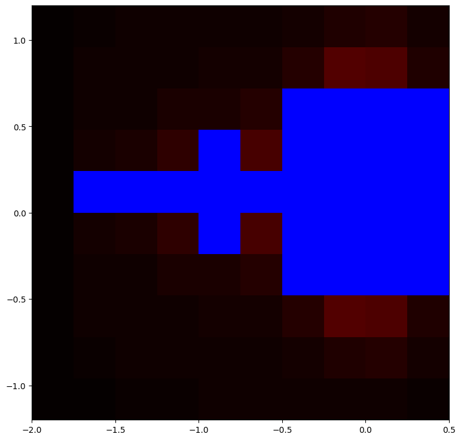

```python
iteration=50
precision=10

xmin=-2
xmax=0.5

ymin=-1.2
ymax=1.2

Mandelbrot(xmin, xmax, ymin, ymax, precision, iteration)
```

```
100.0% de calcul effectué
Calculs pour l'affichage du graphique...
```

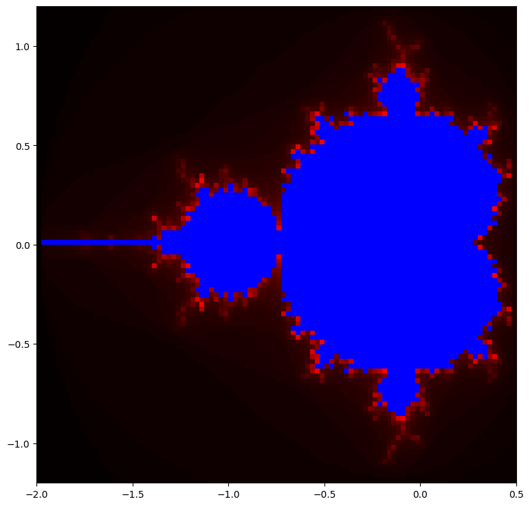

```python
iteration=50
precision=100

xmin=-2
xmax=0.5

ymin=-1.2
ymax=1.2

Mandelbrot(xmin, xmax, ymin, ymax, precision, iteration)
```

```
100.0% de calcul effectué
Calculs pour l'affichage du graphique...
```

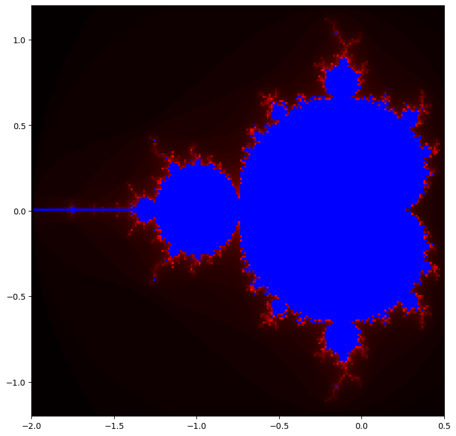

```python
iteration=50
precision=200

xmin=-2
xmax=0.5

ymin=-1.2
ymax=1.2

Mandelbrot(xmin, xmax, ymin, ymax, precision, iteration)
```

```
100.0% de calcul effectué
Calculs pour l'affichage du graphique...
```

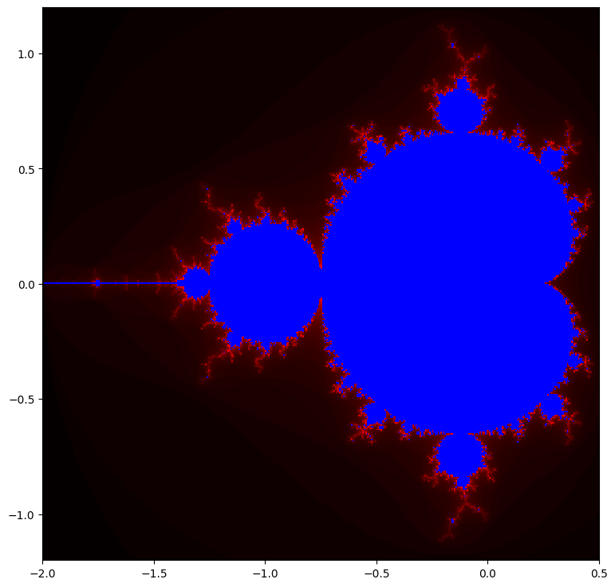

```python
iteration=50
precision=400

xmin=-2
xmax=0.5

ymin=-1.2
ymax=1.2

Mandelbrot(xmin, xmax, ymin, ymax, precision, iteration)
```

Réalisez un zoom élégant dans la vallé des hippocampes

```
100.0% de calcul effectué
Calculs pour l'affichage du graphique...
```

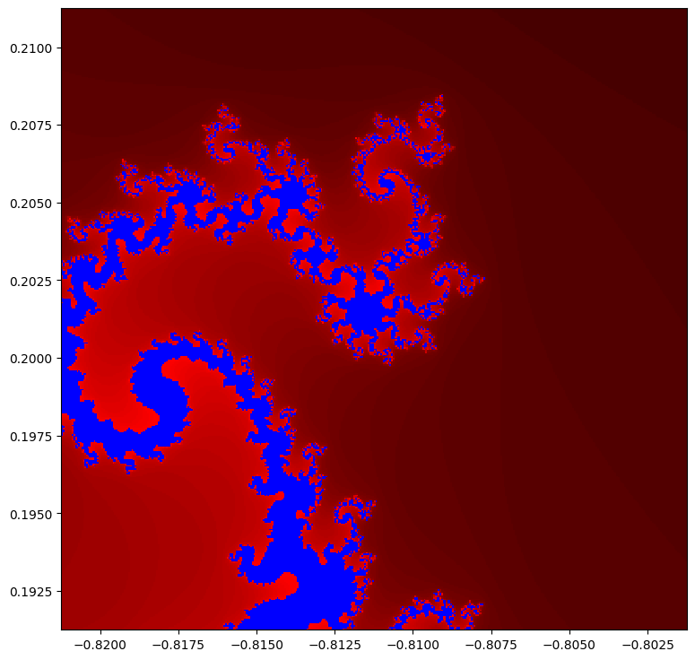

```python
#Zoom intéressant
x=-0.81125
y=0.20125
zoom=0.01

iteration=50
precision=400

xmin=x-zoom
xmax=x+zoom

ymin=y-zoom
ymax=y+zoom

Mandelbrot(xmin, xmax, ymin, ymax, precision, iteration)
```